# slide_deck. slides

## Prosper Loan Data Exploration

##### By Nada Alruwaythi

##### Investigation Overview

- In this investigation, I wanted to figure out two things:
- 1- The variables that can be utilized to forecast credit default.
- 2- What variables determine Prosper's rating.

Dataset Overview This data set contains 113937 loans with 81 variables on each loan, for the purpose of this investigation I've taken the following variables:

- Term
- LoanStatus
- BorrowerRate
- ProsperRating (Alpha)
- LoanOriginalAmount
- ProsperRating (numeric)
- EmploymentStatus
- DelinquenciesLast7Years
- StatedMonthlyIncome
- Recommendations
- Investors
- TotalProsperLoans

## Wrangling

# Univariate Exploration

### Loan status

- The majority of the loans in the data set are current loans. Past-due loans are classified into numerous categories based on the length of the payment delay.
- Another significant factor is completed loans, with defaulted loans constituting a minority.

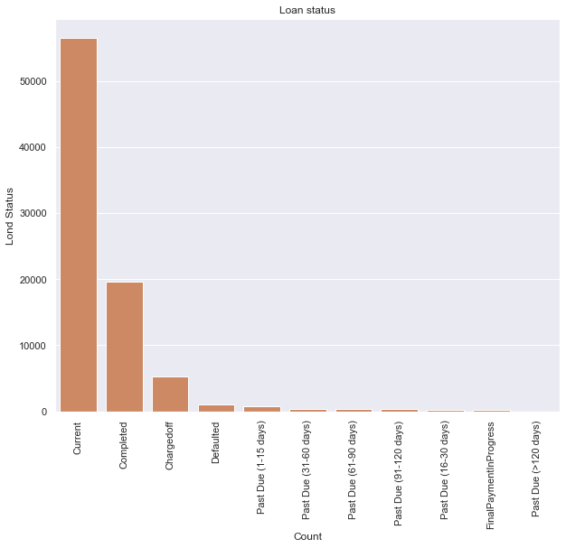

# Bivariate Exploration

- There is insufficient information on part-time, retired, and unemployed borrowers for the job status variable to demonstrate how it interacts with term and Prosper rating factors. However, it is clear that word and Prosper rating interact in some way. There are proportionally more 60-month loans with B and C grades. Borrowers with HR ratings can only get loans for 36 months.

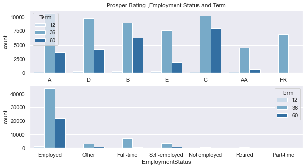

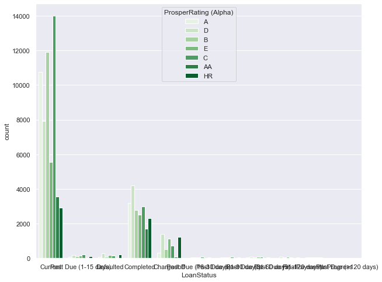

# Multivariate Exploration

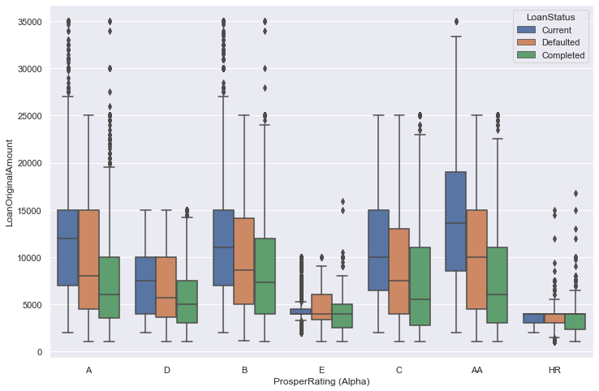

- Except for the lowest ratings defaulted credits tend to be larger than completed.
- Most of the defaulted credits comes from individuals with low Prosper rating

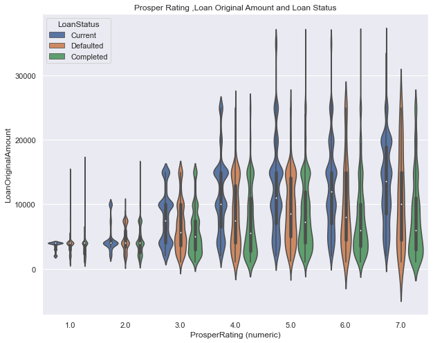